# cblind

Elisa Thouverai

2022-09-21

```r
#Required packages
require(cblindplot)
```

## Introduction

**cblind** package enables colour blind people to easily visualize maps made with various palettes in a “colour blind friendly” format by changing the palette based on the colour blind deficiency selected. In this vignette we will demonstrate how to use the package.

## Input data preparation

The image used as an exaple is colored with rainbow palette and represents the NDVI values of Falzarego in June 2022. To correctly upload the image in R, the function **cblind.prep()** that convert the image in a “SpatRaster” object (**terra** package) can be used:

```r
im <- cblind.prep("rainbow_ndvi.png")
```

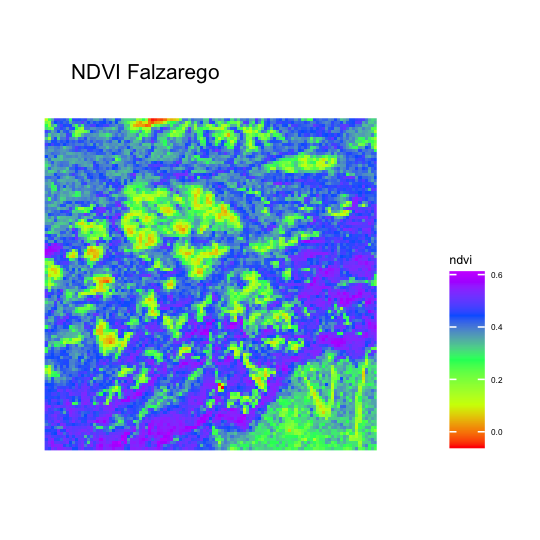

Using the arguments **crop_manual** or **select_class**, the user can crop the image manually or with the use of unsupervised classification in case of an irregular shape, so that the background is excluded.

The **crop_manual** argument enable the user to manually select the area of the image he wants to crop:

```r
im_cr <- cblind.prep("rainbow_ndvi.png", crop_manual = T)
```

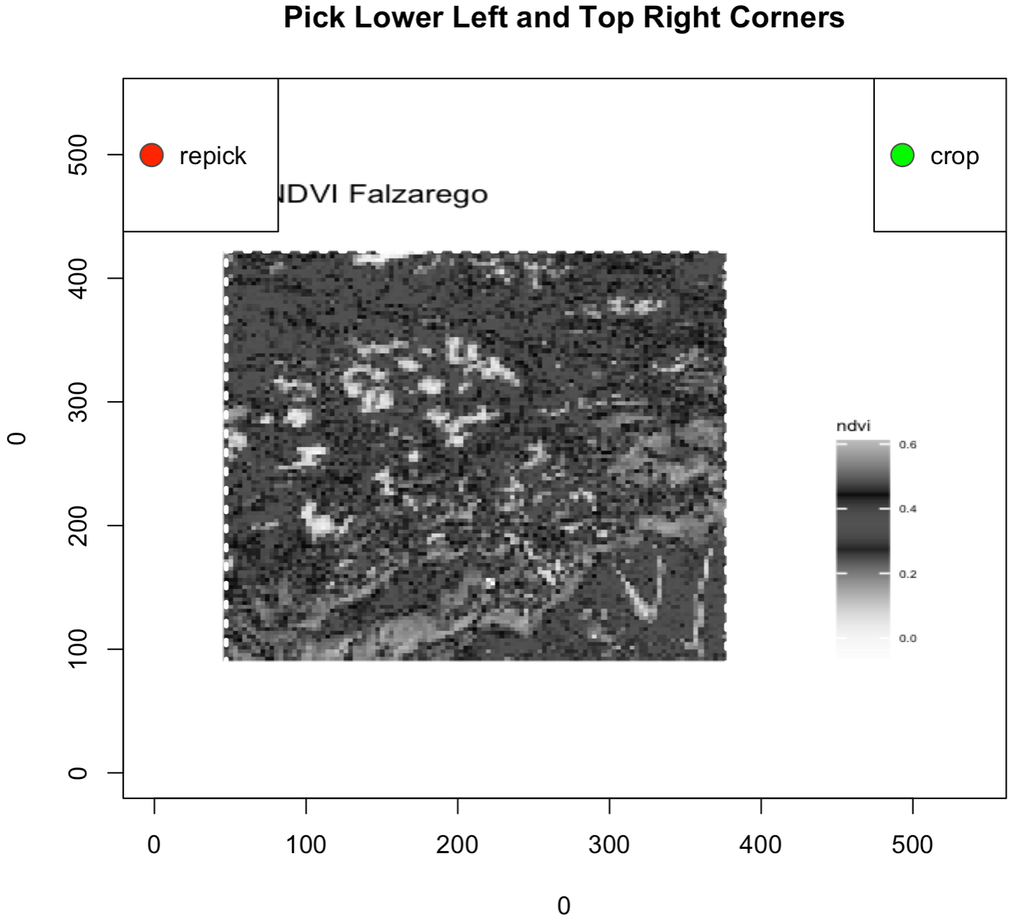

Instead, using the **select_class** argument the map area is selected by the user after an unsupervised classification where the background is separetad from the image:

```r
im_cl <- cblind.prep("rainbow_ndvi.png", select_class = T)
```

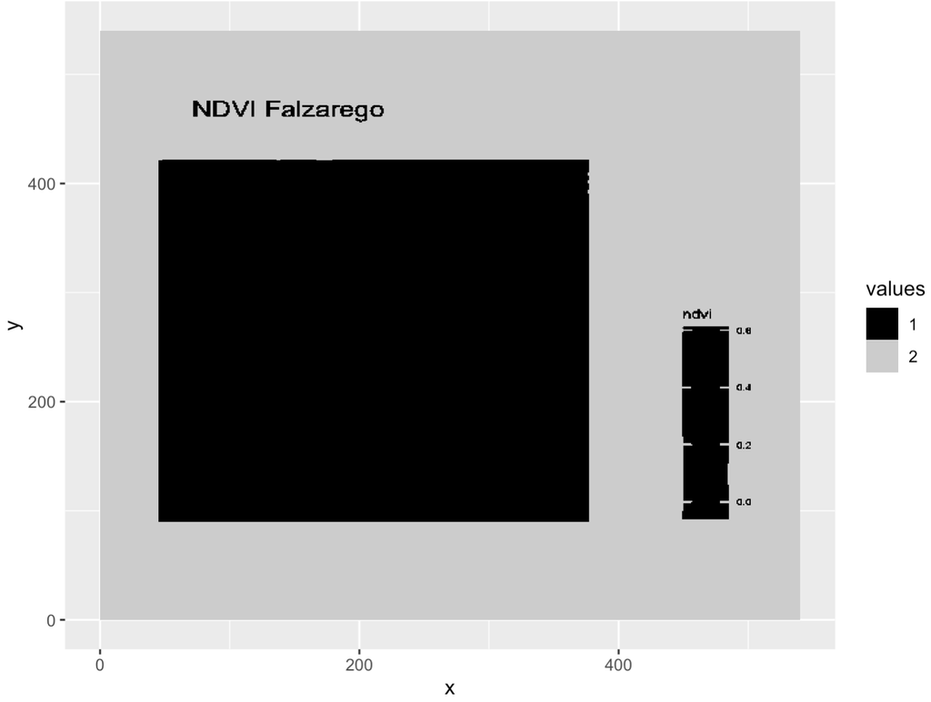

## Plot construction

The image uploaded with **cblind_prep()** function can be now elaborated to change the palette. Here, the image not modified:

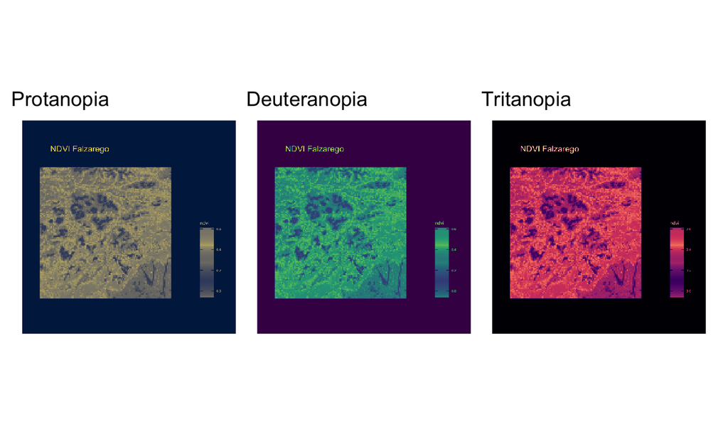

```r
cblind.plot(im, cvd = "protanopia")
cblind.plot(im, cvd = "deuteranopia")
cblind.plot(im, cvd = "tritanopia")
```

As for the manually cropped image:

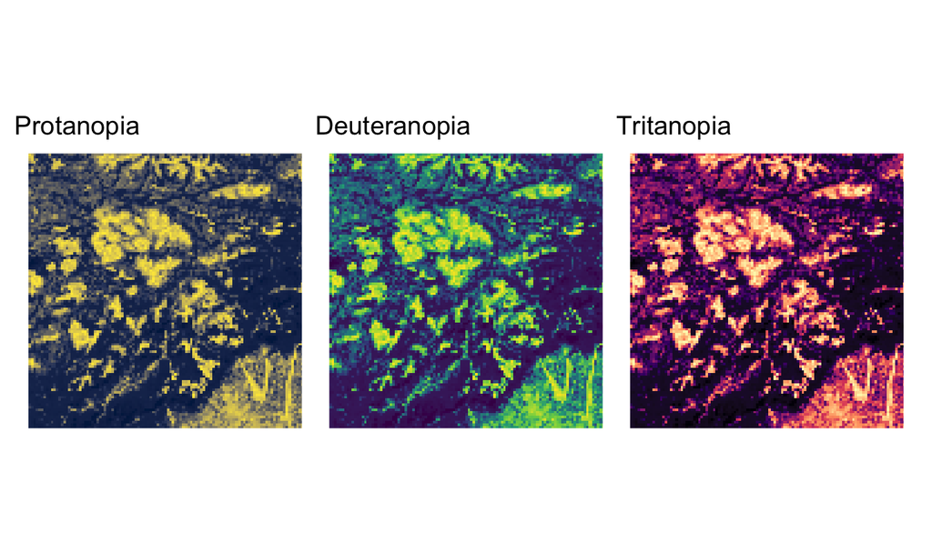

```r
cblind.plot(im_cr, cvd = "protanopia")
cblind.plot(im_cr, cvd = "deuteranopia")
cblind.plot(im_cr, cvd = "tritanopia")
```

And last, the classified image:

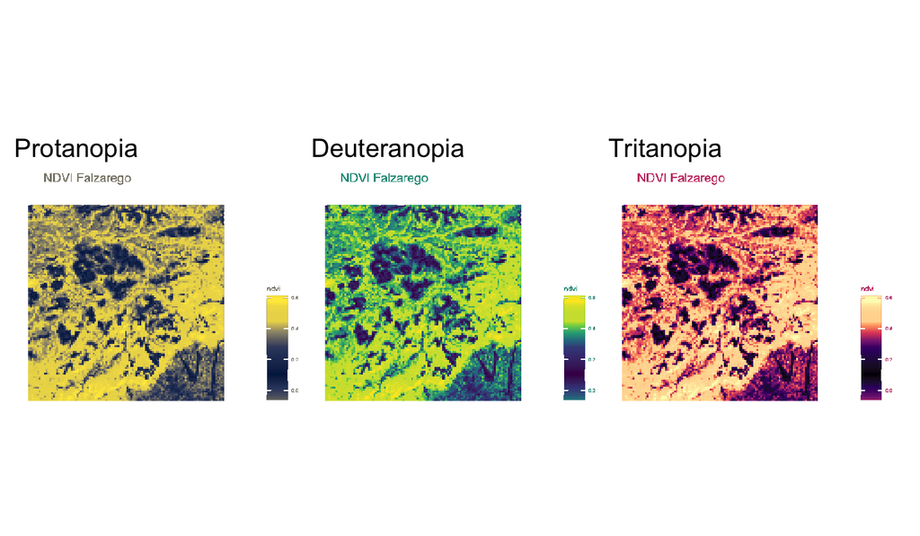

```r
cblind.plot(im_cl, cvd = "protanopia")
cblind.plot(im_cl, cvd = "deuteranopia")
cblind.plot(im_cl, cvd = "tritanopia")
```